# Análisis de datos ómicos - PEC1

Ali_ESSAFI (GitHub repository URL: https://github.com/Aesm24/Essafi-Maamouri-Ali.PEC1.git)

2025-03-23

```r
getwd()
```

```
## [1] "/home/aloulou/Ali_Ess_Maa_PEC1"
```

```r
library(readr)
library(dplyr)
library(metabolomicsWorkbenchR)
```

Cargamos el fichero texto de los resultados del análisis de 12 muestras.

```r
file_path <-"/home/aloulou/Downloads/ST000002_AN000002.txt"

raw_data <- readLines(file_path)
```

Identificamos las líneas del fichero donde aparecen los resultados del análisis.

```r
ms_start <- grep("^MS_METABOLITE_DATA_START", raw_data)
```

```r
ms_end <- grep("^MS_METABOLITE_DATA_END", raw_data)
```

```r
data_lines <- raw_data[(ms_start + 1):(ms_end - 1)]
```

Eliminamos las lineas de datos que contengan campos vacíos.

```r
data_lines <- data_lines[data_lines != ""]
```

Reemplazamos los caracteres de 2 tabs consecutivos que significa la ausencia de valores entre columnas, ya quel formato de dato espera tener valores entre dos tabs. Esto nos permite usar la función read.table.

```r
data_lines <- gsub("\t\t", "\tNA\t", data_lines)
```

Asignamos un dataframe a los datos léidos.

```r
data_df <- read.table(text = paste(data_lines, collapse="\n"), header = TRUE, sep = "\t", check.names = FALSE, fill = TRUE)
```

Verificamos si hay datos NA

```r
sum(is.na(data_df))
```

```
## [1] 0
```

Verificamos las columnas y filas del dataframe creado.

```r
head(data_df)
```

```
##                  Samples                           LabF_684508
## 1                Factors Transplantation:After transplantation
## 2            1-monoolein                             6047.0000
## 3          1-monostearin                             9771.0000
## 4 2-hydroxybutanoic acid                            13238.0000
## 5 2-hydroxyglutaric acid                             7160.0000
## 6  2-ketoisocaproic acid                              812.0000
##                             LabF_684512                           LabF_684516
## 1 Transplantation:After transplantation Transplantation:After transplantation
## 2                             2902.0000                             1452.0000
## 3                             6521.0000                             1302.0000
## 4                            29774.0000                             4134.0000
## 5                            11501.0000                             3202.0000
## 6                             2011.0000                              738.0000
##                             LabF_684520                           LabF_684524
```

[output cut: 34 more lines]

Verificamos el número de columnas en cada línea del dataframe

```r
column_counts <- sapply(strsplit(data_lines, "\t"), length)
table(column_counts)
```

```
## column_counts
##  13
## 144
```

las 144 lineas tienen 13 columnas

```r
head(data_df, 1)
```

```
##   Samples                           LabF_684508
## 1 Factors Transplantation:After transplantation
##                             LabF_684512                           LabF_684516
## 1 Transplantation:After transplantation Transplantation:After transplantation
##                             LabF_684520                           LabF_684524
## 1 Transplantation:After transplantation Transplantation:After transplantation
##                             LabF_684528                            LabF_684483
## 1 Transplantation:After transplantation Transplantation:Before transplantation
##                              LabF_684487                            LabF_684491
## 1 Transplantation:Before transplantation Transplantation:Before transplantation
##                              LabF_684495                            LabF_684499
## 1 Transplantation:Before transplantation Transplantation:Before transplantation
##                              LabF_684503
## 1 Transplantation:Before transplantation
```

Extraemos la primera línea que contiene los nombres de las muestras y el tratamiento aplicado a cada una de ellas.

seleccionamos la primera fila excluyendo la primera columna

```r
factores <- data_df[1, -1]
```

extraemos los metabolitos para luego crear la matriz

```r
metabolites <- data_df[-1, ]
```

Creamos la matriz de los resultados.

Eliminamos la primera columna, convertimos cada elemento del dataframe en un dato numérico.

```r
metabolites_matrix <- as.matrix(apply(metabolites[, -1], 2, as.numeric))
rownames(metabolites_matrix) <- metabolites[, 1]
colnames(metabolites_matrix) <- colnames(metabolites)[-1]
```

Verificamos los valores de la la primera fila de la matriz.

```r
metabolites_matrix[1, ]
```

```
## LabF_684508 LabF_684512 LabF_684516 LabF_684520 LabF_684524 LabF_684528
##        6047        2902        1452        3428        2985       16334
## LabF_684483 LabF_684487 LabF_684491 LabF_684495 LabF_684499 LabF_684503
##      244142        6968        1928       19228        3029       23277
```

Modificamos los nombres de las columnas para incluir la información sobre la condición de transplantación

```r
colnames(metabolites_matrix)[1:6] <- paste0(colnames(metabolites_matrix)[1:6], "_A")
colnames(metabolites_matrix)[7:12] <- paste0(colnames(metabolites_matrix)[7:12], "_B")
```

```r
colnames(metabolites_matrix)
```

```
##  [1] "LabF_684508_A" "LabF_684512_A" "LabF_684516_A" "LabF_684520_A"
##  [5] "LabF_684524_A" "LabF_684528_A" "LabF_684483_B" "LabF_684487_B"
##  [9] "LabF_684491_B" "LabF_684495_B" "LabF_684499_B" "LabF_684503_B"
```

Ya tenemos los nombres de las muestras en la matriz metabolites_matrix con las letras indicando si la muestra ha sido recogida antes, B o después A de la transplantación.

```r
print(factores)
```

```
##                             LabF_684508                           LabF_684512
## 1 Transplantation:After transplantation Transplantation:After transplantation
##                             LabF_684516                           LabF_684520
## 1 Transplantation:After transplantation Transplantation:After transplantation
##                             LabF_684524                           LabF_684528
## 1 Transplantation:After transplantation Transplantation:After transplantation
##                              LabF_684483                            LabF_684487
## 1 Transplantation:Before transplantation Transplantation:Before transplantation
##                              LabF_684491                            LabF_684495
## 1 Transplantation:Before transplantation Transplantation:Before transplantation
##                              LabF_684499                            LabF_684503
## 1 Transplantation:Before transplantation Transplantation:Before transplantation
```

```r
str(factores)
```

```
## 'data.frame':    1 obs. of  12 variables:
##  $ LabF_684508: chr "Transplantation:After transplantation"
##  $ LabF_684512: chr "Transplantation:After transplantation"
##  $ LabF_684516: chr "Transplantation:After transplantation"
##  $ LabF_684520: chr "Transplantation:After transplantation"
##  $ LabF_684524: chr "Transplantation:After transplantation"
##  $ LabF_684528: chr "Transplantation:After transplantation"
##  $ LabF_684483: chr "Transplantation:Before transplantation"
##  $ LabF_684487: chr "Transplantation:Before transplantation"
##  $ LabF_684491: chr "Transplantation:Before transplantation"
##  $ LabF_684495: chr "Transplantation:Before transplantation"
##  $ LabF_684499: chr "Transplantation:Before transplantation"
##  $ LabF_684503: chr "Transplantation:Before transplantation"
```

```r
class(factores)
```

```
## [1] "data.frame"
```

```r
muestras<- colnames(factores)
```

```r
print(muestras)
```

```
##  [1] "LabF_684508" "LabF_684512" "LabF_684516" "LabF_684520" "LabF_684524"
##  [6] "LabF_684528" "LabF_684483" "LabF_684487" "LabF_684491" "LabF_684495"
## [11] "LabF_684499" "LabF_684503"
```

Para la metadata de las muestras y para facilitar el análisis, modificamos también los nombres de las muestras añadiendo “_B” a los nombres de muestras de individuos que no habían tenido transplantación y “_A” de muestras tomadas de individuos que hayan tenido transplantación.

Usamos la función unlist para extraer los valores del dataframe factores en un vector y con la función as.character registramos los valores en formato texto.

```r
vector_factores<- as.character(unlist(factores))
```

En el vector factores reemplazamos “Transplantation:” por una cadena vacía (empty string)

```r
vector_factores <- gsub("Transplantation:", "", vector_factores)
```

```r
print(vector_factores)
```

```
##  [1] "After transplantation"  "After transplantation"  "After transplantation"
##  [4] "After transplantation"  "After transplantation"  "After transplantation"
##  [7] "Before transplantation" "Before transplantation" "Before transplantation"
## [10] "Before transplantation" "Before transplantation" "Before transplantation"
```

Ahora con la función grepl buscamos las palabras After y Before para cambiarlas respectivamente con las etiquetas _A y _B

```r
etiquetas_muestras<- ifelse(grepl("After", vector_factores), paste0(muestras, "_A"), paste0(muestras, "_B"))
```

```r
print(etiquetas_muestras)
```

```
##  [1] "LabF_684508_A" "LabF_684512_A" "LabF_684516_A" "LabF_684520_A"
##  [5] "LabF_684524_A" "LabF_684528_A" "LabF_684483_B" "LabF_684487_B"
##  [9] "LabF_684491_B" "LabF_684495_B" "LabF_684499_B" "LabF_684503_B"
```

Ahora preparamos el sample_metadata

```r
sample_metadata<- data.frame(
  Sample = etiquetas_muestras,
  Transplantation = vector_factores,
  row.names = etiquetas_muestras
)
```

```r
print(sample_metadata)
```

```
##                      Sample        Transplantation
## LabF_684508_A LabF_684508_A  After transplantation
## LabF_684512_A LabF_684512_A  After transplantation
## LabF_684516_A LabF_684516_A  After transplantation
## LabF_684520_A LabF_684520_A  After transplantation
## LabF_684524_A LabF_684524_A  After transplantation
## LabF_684528_A LabF_684528_A  After transplantation
## LabF_684483_B LabF_684483_B Before transplantation
## LabF_684487_B LabF_684487_B Before transplantation
## LabF_684491_B LabF_684491_B Before transplantation
## LabF_684495_B LabF_684495_B Before transplantation
## LabF_684499_B LabF_684499_B Before transplantation
## LabF_684503_B LabF_684503_B Before transplantation
```

Identificamos la tabla de anotaciones (annotation table) la lista de metadata de metabolitos a partir del fichero texto de raw_data. Los metadata están listados entre METABOLITES_START y METABOLITES_END y resgistramos los datos en un dataframe metadata_df.

```r
metabolite_start <- grep("^METABOLITES_START", raw_data)
```

```r
metabolite_end <- grep("^METABOLITES_END", raw_data)
```

```r
annotation_table<- raw_data[(metabolite_start + 1):(metabolite_end  - 1)]
```

```r
annotation_table <- annotation_table[annotation_table != ""]
```

Buscamos los datos ausentes y ponemos en los campos vacios NA

```r
annotation_table <- gsub("\t\t", "\tNA\t", annotation_table)
```

```r
metadata_df <- read.table(text = paste(annotation_table, collapse="\n"), header = TRUE, sep = "\t", check.names = FALSE, fill = TRUE)
```

Preparación del dataframe de metadata del metabolitos: rowData

Para evitar posibles problemas al crear el SummarizedExperiment cambiamos NA por “Unknown”

```r
metadata_df$inchi_key[is.na(metadata_df$inchi_key)] <- "Unknown"
```

```r
str(annotation_table )
```

```
##  chr [1:143] "metabolite_name\tmoverz_quant\tri\tri_type\tpubchem_id\tinchi_key\tkegg_id\tother_id\tother_id_type" ...
```

```r
str(metadata_df)
```

```
## 'data.frame':    142 obs. of  9 variables:
##  $ metabolite_name: chr  "1-monoolein" "1-monostearin" "2-hydroxybutanoic acid" "2-hydroxyglutaric acid" ...
##  $ moverz_quant   : int  129 399 131 129 200 218 218 102 191 177 ...
##  $ ri             : int  952993 959625 258175 506359 310629 889972 948845 309799 278929 269975 ...
##  $ ri_type        : chr  "Fiehn" "Fiehn" "Fiehn" "Fiehn" ...
##  $ pubchem_id     : int  5283468 107036 11266 43 70 123409 NA 64956 11266 68152 ...
##  $ inchi_key      : chr  "Unknown" "Unknown" "Unknown" "Unknown" ...
##  $ kegg_id        : chr  "" "D01947" "C05984" "C02630" ...
##  $ other_id       : int  213963 202835 199800 214409 213388 233239 227282 213161 199774 232649 ...
##  $ other_id_type  : chr  "BinBase" "BinBase" "BinBase" "BinBase" ...
```

Hacemos una serie de comprobaciones antes de crear el SummarizedExperiment Object

```r
nrow(metabolites_matrix)
```

```
## [1] 142
```

```r
nrow(metadata_df)
```

```
## [1] 142
```

```r
head(rownames(metabolites_matrix))
```

```
## [1] "1-monoolein"            "1-monostearin"          "2-hydroxybutanoic acid"
## [4] "2-hydroxyglutaric acid" "2-ketoisocaproic acid"  "2-monopalmitin"
```

```r
head(metadata_df$metabolite_name)
```

```
## [1] "1-monoolein"            "1-monostearin"          "2-hydroxybutanoic acid"
## [4] "2-hydroxyglutaric acid" "2-ketoisocaproic acid"  "2-monopalmitin"
```

```r
tail(rownames(metabolites_matrix))
```

```
## [1] "urea"      "uric acid" "uridine"   "valine"    "xanthine"  "xylose"
```

```r
tail(metadata_df$metabolite_name)
```

```
## [1] "urea"      "uric acid" "uridine"   "valine"    "xanthine"  "xylose"
```

```r
missing_metabolites <- setdiff(metadata_df$metabolite_name, rownames(metabolites_matrix))
print(missing_metabolites)
```

```
## character(0)
```

```r
metadata_df <- metadata_df[!is.na(metadata_df$metabolite_name), ]
```

rowData o metadata_df

```r
metadata_df <- data.frame(
  metabolite_name = metadata_df$metabolite_name,
  moverz_quant = metadata_df$moverz_quant,
  ri = metadata_df$ri,
  ri_type = metadata_df$ri_type,
  pubchem_id = metadata_df$pubchem_id,
  inchi_key = metadata_df$inchi_key,
  kegg_id = metadata_df$kegg_id,
  other_id = metadata_df$other_id,
  other_id_type = metadata_df$other_id_type,
  row.names = metadata_df$metabolite_name
)
```

```r
library(SummarizedExperiment)
colnames(metabolites_matrix)
```

```
##  [1] "LabF_684508_A" "LabF_684512_A" "LabF_684516_A" "LabF_684520_A"
##  [5] "LabF_684524_A" "LabF_684528_A" "LabF_684483_B" "LabF_684487_B"
##  [9] "LabF_684491_B" "LabF_684495_B" "LabF_684499_B" "LabF_684503_B"
```

```r
print(sample_metadata)
```

```
##                      Sample        Transplantation
## LabF_684508_A LabF_684508_A  After transplantation
## LabF_684512_A LabF_684512_A  After transplantation
## LabF_684516_A LabF_684516_A  After transplantation
## LabF_684520_A LabF_684520_A  After transplantation
## LabF_684524_A LabF_684524_A  After transplantation
## LabF_684528_A LabF_684528_A  After transplantation
## LabF_684483_B LabF_684483_B Before transplantation
## LabF_684487_B LabF_684487_B Before transplantation
## LabF_684491_B LabF_684491_B Before transplantation
## LabF_684495_B LabF_684495_B Before transplantation
## LabF_684499_B LabF_684499_B Before transplantation
## LabF_684503_B LabF_684503_B Before transplantation
```

```r
SumExp <- SummarizedExperiment(
  assays = list(counts = metabolites_matrix),
  colData = sample_metadata,
  rowData = metadata_df
)
```

```r
# Verificar si los nombres de las filas entre la matriz de datos y rowData son identicos
print(identical(rownames(metabolites_matrix), rownames(rowData)))
```

```
## [1] FALSE
```

```r
# Verificar si los nombres de las columnas son identicos entre la matriz de datos y el colData
print(identical(colnames(metabolites_matrix), rownames(colData)))
```

```
## [1] FALSE
```

```r
# exponer la lista de los nombres de las filas y de las columnas para evitar posibles problemas, aunque esto ya se ha comprobado antes de crear el SummarizedExperiment Object
cat("Assay rownames:\n")
```

```
## Assay rownames:
```

```r
print(rownames(metabolites_matrix))
```

```
##   [1] "1-monoolein"                 "1-monostearin"
##   [3] "2-hydroxybutanoic acid"      "2-hydroxyglutaric acid"
##   [5] "2-ketoisocaproic acid"       "2-monopalmitin"
##   [7] "2-monostearin NIST"          "3-aminoisobutyric acid"
##   [9] "3-hydroxybutanoic acid"      "3-hydroxypropionic acid"
##  [11] "3-phenyllactic acid"         "5-aminovaleric acid"
##  [13] "acetohydroxamic acid"        "acetophenone NIST"
##  [15] "adipic acid"                 "alanine"
##  [17] "alpha ketoglutaric acid"     "aminomalonate"
##  [19] "arabinose"                   "arabitol"
##  [21] "arachidic acid"              "arachidonic acid"
##  [23] "arginine + ornithine"        "asparagine"
##  [25] "aspartic acid"               "behenic acid"
##  [27] "benzoic acid"                "benzylalcohol"
##  [29] "beta-alanine"                "beta-gentiobiose"
```

[output cut: 56 more lines]

```r
cat("rowData rownames:\n")
```

```
## rowData rownames:
```

```r
print(rownames(rowData))
```

[output not shown]

```r
cat("Assay colnames:\n")
```

```
## Assay colnames:
```

```r
print(colnames(metabolites_matrix))
```

```
##  [1] "LabF_684508_A" "LabF_684512_A" "LabF_684516_A" "LabF_684520_A"
##  [5] "LabF_684524_A" "LabF_684528_A" "LabF_684483_B" "LabF_684487_B"
##  [9] "LabF_684491_B" "LabF_684495_B" "LabF_684499_B" "LabF_684503_B"
```

```r
cat("colData rownames:\n")
```

```
## colData rownames:
```

```r
print(rownames(colData))
```

[output not shown]

Guardamos el objeto SummarizedExperiment en formato Rda que pasaremos al repositorio de Github ya creado.

```r
save(SumExp, file="SumExp_ST000002_AN000002.Rda")
```

```r
load("SumExp_ST000002_AN000002.Rda")
```

Visualizamos la matriz de datos:

```r
assay(SumExp)
```

```
##                             LabF_684508_A LabF_684512_A LabF_684516_A
## 1-monoolein                          6047          2902          1452
## 1-monostearin                        9771          6521          1302
## 2-hydroxybutanoic acid              13238         29774          4134
## 2-hydroxyglutaric acid               7160         11501          3202
## 2-ketoisocaproic acid                 812          2011           738
## 2-monopalmitin                       1511           622           883
## 2-monostearin NIST                   2060           938           397
## 3-aminoisobutyric acid               9147         40522         22759
## 3-hydroxybutanoic acid              19381         11203         11711
## 3-hydroxypropionic acid              2166          8594          3124
## 3-phenyllactic acid                  2633          7480          3305
## 5-aminovaleric acid               1501190        836534        711249
## acetohydroxamic acid                  662          2877          1952
## acetophenone NIST                    3382         10745          6759
## adipic acid                           825          3490          1417
## alanine                           1270281       1391469        861432
## alpha ketoglutaric acid               240           347           215
## aminomalonate                        2511          5903          1736
## arabinose                             867           965          1427
## arabitol                             1534          1147          1232
## arachidic acid                        924           874          5941
## arachidonic acid                    35469          8788          8700
## arginine + ornithine               182457         96805         50449
## asparagine                          20202         18288         18715
## aspartic acid                       99548        305598        155995
## behenic acid                         8140         14017         28915
## benzoic acid                         4714         74353          5003
## benzylalcohol                        2772         14543          6383
## beta-alanine                         1075          2013           783
## beta-gentiobiose                      616          1199           381
## beta-sitosterol                      4527         14937          4937
## caffeic acid                         1107          3499           769
## cerotic acid                          674          2773          1319
## cholesterol                        834010       2165933        149124
## citric acid                          3849          1943           778
## citrulline                          40775         18557         16120
## creatinine                         170545         21561         63410
## cyano-L-alanine                       107           480           237
## cysteine                            18679         30162          8226
```

[output cut: 517 more lines]

```
## threitol                             1888          2069          3735
## threonic acid                        2010          1391          3182
## threonine                          652641        400377        116377
## tocopherol                            558           896          7983
## trehalose                          294943          3723           493
## tryptophan                         560080        407006        732294
## tyramine                           110296        405325        182129
## tyrosine                           982733        967974        384097
## uracil                              19191          4059         22004
## urea                                42533        599406          4305
## uric acid                           66759        327982        136704
## uridine                              2915           190           246
## valine                            1307288       1073522       1080473
## xanthine                             4236           282          3798
## xylose                               6323          9324          1007
```

Generamos un fichero texto con los niveles de metabolitos obtenidos con el ensayo hecho con 12 muestras (6 antes y 6 después de la transplantación) que pasaremos al repositorio de Github ya creado.

```r
write.table(assay(SumExp), file = "assay_ST000002.txt", sep = "\t", row.names = TRUE, col.names = NA, quote = FALSE)
```

Hacemos más comprobaciones

```r
print(colData)
```

[output not shown]

```r
colData(SumExp)
```

```
## DataFrame with 12 rows and 2 columns
##                      Sample        Transplantation
##                 <character>            <character>
## LabF_684508_A LabF_684508_A  After transplantation
## LabF_684512_A LabF_684512_A  After transplantation
## LabF_684516_A LabF_684516_A  After transplantation
## LabF_684520_A LabF_684520_A  After transplantation
## LabF_684524_A LabF_684524_A  After transplantation
## ...                     ...                    ...
## LabF_684487_B LabF_684487_B Before transplantation
## LabF_684491_B LabF_684491_B Before transplantation
## LabF_684495_B LabF_684495_B Before transplantation
## LabF_684499_B LabF_684499_B Before transplantation
## LabF_684503_B LabF_684503_B Before transplantation
```

```r
str(colData(SumExp))
```

```
## Formal class 'DFrame' [package "S4Vectors"] with 6 slots
##   ..@ rownames       : chr [1:12] "LabF_684508_A" "LabF_684512_A" "LabF_684516_A" "LabF_684520_A" ...
##   ..@ nrows          : int 12
##   ..@ elementType    : chr "ANY"
##   ..@ elementMetadata: NULL
##   ..@ metadata       : list()
##   ..@ listData       :List of 2
##   .. ..$ Sample         : chr [1:12] "LabF_684508_A" "LabF_684512_A" "LabF_684516_A" "LabF_684520_A" ...
##   .. ..$ Transplantation: chr [1:12] "After transplantation" "After transplantation" "After transplantation" "After transplantation" ...
```

```r
rowData(SumExp)
```

```
## DataFrame with 142 rows and 9 columns
##                               metabolite_name moverz_quant        ri
##                                   <character>    <integer> <integer>
## 1-monoolein                       1-monoolein          129    952993
## 1-monostearin                   1-monostearin          399    959625
## 2-hydroxybutanoic acid 2-hydroxybutanoic acid          131    258175
## 2-hydroxyglutaric acid 2-hydroxyglutaric acid          129    506359
## 2-ketoisocaproic acid   2-ketoisocaproic acid          200    310629
## ...                                       ...          ...       ...
## uric acid                           uric acid          441    731185
## uridine                               uridine          258    856953
## valine                                 valine          144    313224
## xanthine                             xanthine          353    702391
## xylose                                 xylose          103    542808
##                            ri_type pubchem_id   inchi_key     kegg_id  other_id
##                        <character>  <integer> <character> <character> <integer>
## 1-monoolein                  Fiehn    5283468     Unknown                213963
## 1-monostearin                Fiehn     107036     Unknown      D01947    202835
## 2-hydroxybutanoic acid       Fiehn      11266     Unknown      C05984    199800
## 2-hydroxyglutaric acid       Fiehn         43     Unknown      C02630    214409
## 2-ketoisocaproic acid        Fiehn         70     Unknown      C00233    213388
## ...                            ...        ...         ...         ...       ...
## uric acid                    Fiehn       1175     Unknown      C00366    221495
## uridine                      Fiehn       6029     Unknown      C00299    213127
## valine                       Fiehn       6287     Unknown      C00183    199605
## xanthine                     Fiehn       1188     Unknown      C00385    203224
## xylose                       Fiehn     135191     Unknown      C00181    200500
##                        other_id_type
##                          <character>
## 1-monoolein                  BinBase
## 1-monostearin                BinBase
## 2-hydroxybutanoic acid       BinBase
## 2-hydroxyglutaric acid       BinBase
## 2-ketoisocaproic acid        BinBase
## ...                              ...
## uric acid                    BinBase
## uridine                      BinBase
## valine                       BinBase
## xanthine                     BinBase
## xylose                       BinBase
```

```r
library(knitr)
library(rmarkdown)

cat(
"---
title: 'metabolites_samples_meta'
output: html_document
---


Este fichero contiene metadatos de los metabolitos analizados

STUDY_ID: ST000002
PROJECT_TITLE: Intestinal Samples II pre/post transplantation
PROJECT_TYPE: Human intestinal samples
INSTITUTE: University of California, Davis
DEPARTMENT: Davis Genome Center
LABORATORY: Fiehn
LAST_NAME: Fiehn
FIRST_NAME: Olivier
STUDY_TITLE: Intestinal Samples II pre/post transplantation
STUDY_TYPE: MS Analysis
LAST_NAME: Hartman
FIRST_NAME: Amber
NUMBER_GROUPS: 2
TOTAL_SUBJECTS: 12
SUBJECT_SPECIES: Homo sapiens

", file = "metabolites_samples_meta.md")

# adjuntamos el primer dataframe de metadata
write.table(sample_metadata, file = "metabolites_samples_meta.md", sep = "\t",
            row.names = TRUE, col.names = NA, quote = FALSE, append = TRUE)
```

```r
# añadimos la descripción
cat(
"\n\n**Sample and Instrument Information:**\n

SAMPLE_TYPE: Tissue
TR:TREATMENT_PROTOCOL_COMMENTS: Before transplantation | After transplantation
SP:EXTRACTION_METHOD: Extraction: Proteomics 2004, 4, 78-83; Splitratio: splitless 25 purge
CHROMATOGRAPHY_TYPE: GC
INSTRUMENT_NAME: Agilent 6890N
ANALYSIS_TYPE: MS
INSTRUMENT_NAME: Leco Pegasus III GC TOF
INSTRUMENT_TYPE: GC-TOF
MS_TYPE: EI
MS:ION_MODE: POSITIVE
MS_METABOLITE_DATA:UNITS: Peak height

", file = "metabolites_samples_meta.md", append = TRUE)

# Añadimos el segundo dataframe de datos de las muestras
write.table(metadata_df, file = "metabolites_samples_meta.md", sep = "\t",
            row.names = TRUE, col.names = NA, quote = FALSE, append = TRUE)
dim(SumExp)
```

```
## [1] 142  12
```

```r
head(assay(SumExp))
```

```
##                        LabF_684508_A LabF_684512_A LabF_684516_A LabF_684520_A
## 1-monoolein                     6047          2902          1452          3428
## 1-monostearin                   9771          6521          1302          2781
## 2-hydroxybutanoic acid         13238         29774          4134          4419
## 2-hydroxyglutaric acid          7160         11501          3202         17238
## 2-ketoisocaproic acid            812          2011           738          2550
## 2-monopalmitin                  1511           622           883           796
##                        LabF_684524_A LabF_684528_A LabF_684483_B LabF_684487_B
## 1-monoolein                     2985         16334        244142          6968
## 1-monostearin                   5789          4338         16848         10206
## 2-hydroxybutanoic acid         13334          2115         11587         65635
## 2-hydroxyglutaric acid         20376          1109          8276         12402
## 2-ketoisocaproic acid            871           628          2096          3472
## 2-monopalmitin                   623          5716          3405          3196
##                        LabF_684491_B LabF_684495_B LabF_684499_B LabF_684503_B
## 1-monoolein                     1928         19228          3029         23277
## 1-monostearin                   9398          1013          4190         11114
## 2-hydroxybutanoic acid         32433          1823          4429         30427
## 2-hydroxyglutaric acid         20964         25913          2709         70972
## 2-ketoisocaproic acid          10669           432          1055          1005
## 2-monopalmitin                  1457          1416          1275         14445
```

Resúmen estadistico de la matriz de datos del objeto SummaryExperiment

```r
summary(assay(SumExp))
```

```
##  LabF_684508_A     LabF_684512_A     LabF_684516_A     LabF_684520_A
##  Min.   :     95   Min.   :    336   Min.   :     98   Min.   :    186
##  1st Qu.:   1261   1st Qu.:   2815   1st Qu.:    911   1st Qu.:   2214
##  Median :   4728   Median :  10370   Median :   4877   Median :   5989
##  Mean   : 140978   Mean   : 141017   Mean   : 141063   Mean   : 140922
##  3rd Qu.:  52750   3rd Qu.:  60511   3rd Qu.:  36756   3rd Qu.:  33838
##  Max.   :1665633   Max.   :2165933   Max.   :7204190   Max.   :4694846
##  LabF_684524_A     LabF_684528_A      LabF_684483_B     LabF_684487_B
##  Min.   :    114   Min.   :      48   Min.   :    309   Min.   :    192
##  1st Qu.:   1527   1st Qu.:     592   1st Qu.:   2449   1st Qu.:   2051
##  Median :   7428   Median :    3164   Median :  10900   Median :  12006
##  Mean   : 140911   Mean   :  140966   Mean   : 141038   Mean   : 141185
##  3rd Qu.:  67985   3rd Qu.:   17146   3rd Qu.:  41716   3rd Qu.:  63356
##  Max.   :2498885   Max.   :12543992   Max.   :3937010   Max.   :5370106
##  LabF_684491_B     LabF_684495_B     LabF_684499_B     LabF_684503_B
##  Min.   :    464   Min.   :     88   Min.   :    164   Min.   :     67
##  1st Qu.:   3004   1st Qu.:   2449   1st Qu.:   1592   1st Qu.:   3474
##  Median :   9611   Median :  10563   Median :   5836   Median :  11010
##  Mean   : 141187   Mean   : 140878   Mean   : 140910   Mean   : 141294
##  3rd Qu.:  81266   3rd Qu.:  59358   3rd Qu.:  67631   3rd Qu.:  69077
##  Max.   :2458026   Max.   :1515847   Max.   :3434602   Max.   :2754573
```

```r
colnames(metabolites_matrix)
```

```
##  [1] "LabF_684508_A" "LabF_684512_A" "LabF_684516_A" "LabF_684520_A"
##  [5] "LabF_684524_A" "LabF_684528_A" "LabF_684483_B" "LabF_684487_B"
##  [9] "LabF_684491_B" "LabF_684495_B" "LabF_684499_B" "LabF_684503_B"
```

```r
rownames(colData)
```

[output not shown]

```r
sum(is.na(assay(SumExp)))
```

```
## [1] 0
```

Verificamos la distribución de los niveles de metabolitos en los datos experimentales.

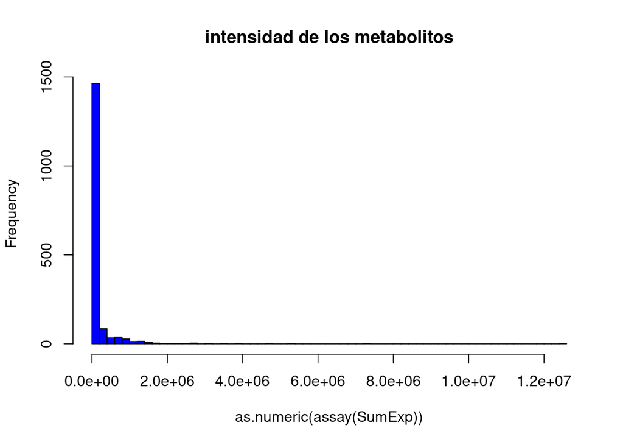

```r
hist(as.numeric(assay(SumExp)), breaks = 50, main = "intensidad de los metabolitos", col = "blue")
```

Se puede ver que la distribución de losniveles de metabolitos no sigue una distribución normal. Por ello, necesitamos aplicar una normalización de los datos aplicando una transformación logaritmica que nos permitira aplicar varios tests y analisis que exigen la normalidad de los datos como el analisis PCA.

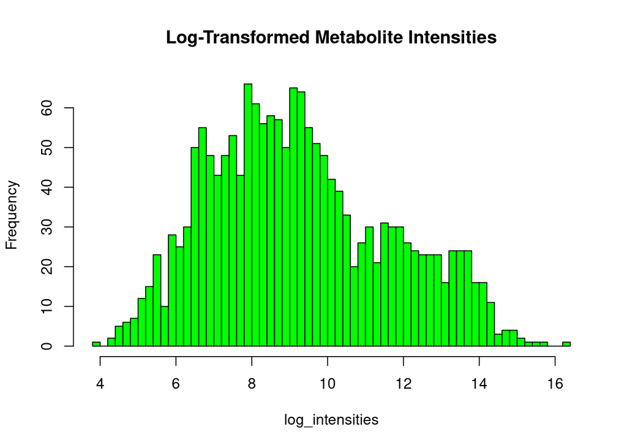

```r
log_intensities <- log1p((assay(SumExp)))
hist(log_intensities, breaks = 50, main = "Log-Transformed Metabolite Intensities", col = "green")
```

cálculo de la varianza entre metabolítos

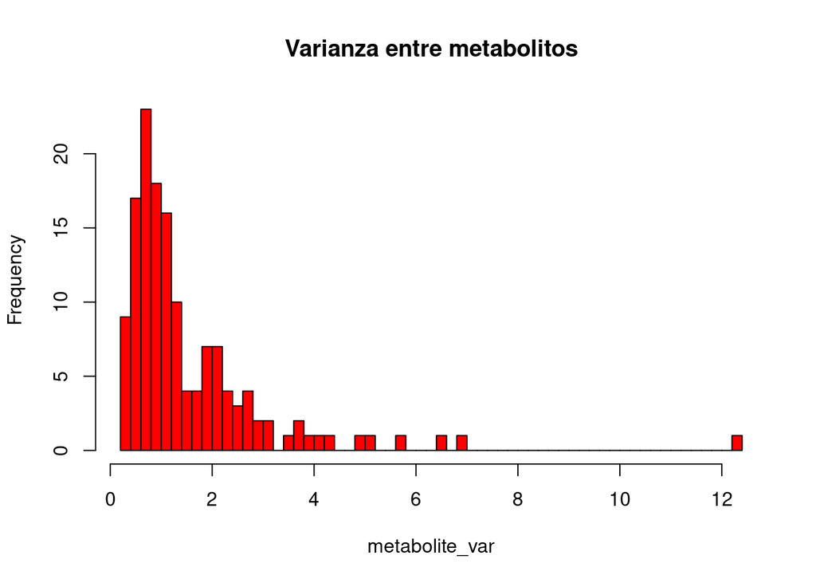

```r
metabolite_var <- apply(log_intensities, 1, var)
hist(metabolite_var, breaks = 50, main = "Varianza entre metabolitos", col = "red")
```

Para el estudio del efecto de la transplantación o no sobre los niveles de metabolitos, no conviene tener metabolitos con varianza de casi 0. Por ello, decidimos eliminar aquellos metabolitos con varianza que avoisina zero.

```r
high_var_metabolites <- metabolite_var > 1e-10
filtered_log_intensities <- log_intensities[high_var_metabolites, ]
```

Verificamos si quedan metabolitos con zero varianza.

```r
sum(apply(filtered_log_intensities, 1, var) == 0)
```

```
## [1] 0
```

desde el objeto SummarizedExperiment SumExp extraemos los nombres de las muestras y dependiendo de si se termina el nombre con una A o una B, se indica el status de la transplantación (After o Before)

```r
sample_names <- colnames(SumExp)
```

```r
# Se crea la columna Transplantation en base de si el nombre se termina por A o B
transplantation_status <- ifelse(grepl("_A$", sample_names), "After", "Before")
```

```r
# Actualizamos colData con la nueva columna que consiste en el estatus de la transplantación (Antes o Después). Se usa la función factor () para la variable categorica transplantation_status.
colData(SumExp)$Transplantation <- factor(transplantation_status)
```

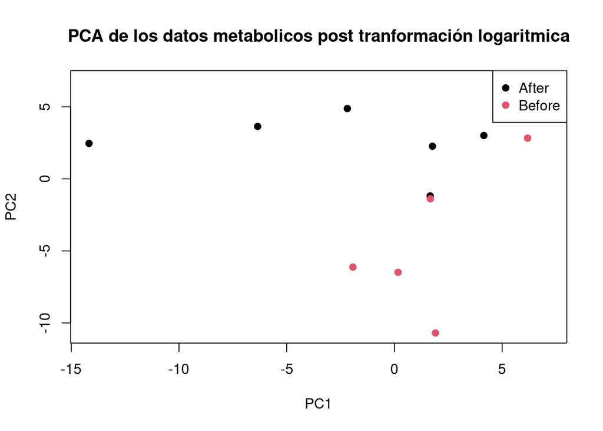

```r
pca <- prcomp(t(filtered_log_intensities), scale. = TRUE)

plot(pca$x[, 1], pca$x[, 2], col = as.factor(colData(SumExp)$Transplantation), pch = 19,
     xlab = "PC1", ylab = "PC2", main = "PCA de los datos metabolicos post tranformación logaritmica")
legend("topright", legend = levels(colData(SumExp)$Transplantation),
       col = 1:length(levels(colData(SumExp)$Transplantation)), pch = 19)
```

Otra forma de visualizar los componentes principales es con el Screeplt. Aqui pongo dos maneras de obtenerlo

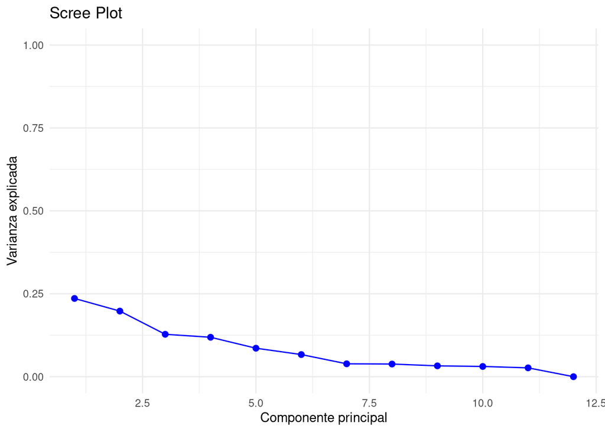

```r
pca <- prcomp(t(filtered_log_intensities), scale. = TRUE)
var_explicada <- (pca$sdev)^2 / sum((pca$sdev)^2)
library(ggplot2)

qplot(1:length(var_explicada), var_explicada) +
  geom_line(color = "blue") +
  geom_point(size = 2, color = "blue") +
  xlab("Componente principal") +
  ylab("Varianza explicada") +
  ggtitle("Scree Plot") +
  ylim(0, 1) +
  theme_minimal()
```

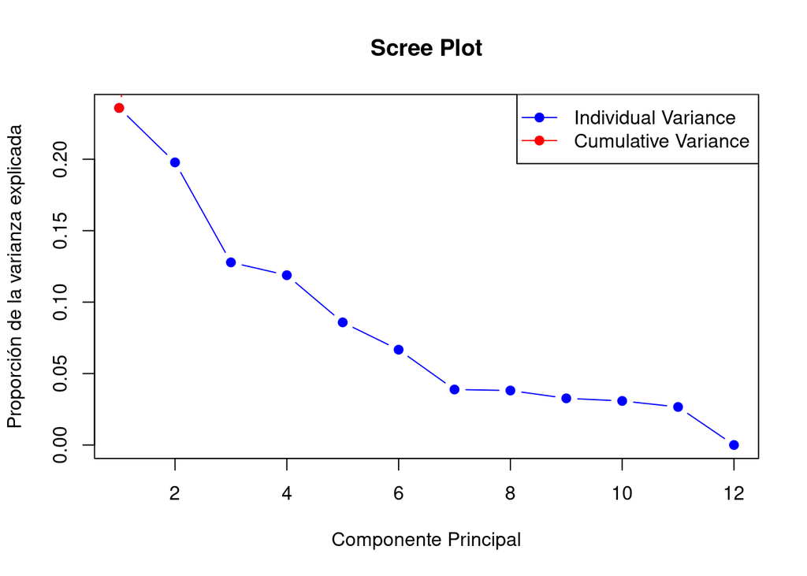

```r
plot(var_explicada, type = "b",
     xlab = "Componente Principal",
     ylab = "Proporción de la varianza explicada",
     main = "Scree Plot",
     pch = 19, col = "blue")

varianza_acumulada<- cumsum(var_explicada)
lines(varianza_acumulada, type = "b", col = "red", pch = 19)


legend("topright", legend = c("Individual Variance", "Cumulative Variance"),
       col = c("blue", "red"), pch = 19, lty = 1)
```

En ambas figuras se puede observar una pendiente importante de la curba con los primeros componentes principales. Indicando que gran parte de la varianza está explicada por los primeros componentes. A partir del sexto componente ya no es necesario añadir más componentes.Con los 6 primeros componentes ya tenemos casi 83% de la varianza explicada, como se puede ver en el resumen d ela PCA.

```r
summary(pca)
```

```
## Importance of components:
##                           PC1    PC2    PC3    PC4     PC5     PC6     PC7
## Standard deviation     5.7877 5.2996 4.2603 4.1081 3.49110 3.07783 2.34846
## Proportion of Variance 0.2359 0.1978 0.1278 0.1188 0.08583 0.06671 0.03884
## Cumulative Proportion  0.2359 0.4337 0.5615 0.6804 0.76619 0.83290 0.87174
##                            PC8     PC9    PC10    PC11      PC12
## Standard deviation     2.32703 2.15383 2.09281 1.94407 5.397e-15
## Proportion of Variance 0.03813 0.03267 0.03084 0.02662 0.000e+00
## Cumulative Proportion  0.90987 0.94254 0.97338 1.00000 1.000e+00
```

```r
class(filtered_log_intensities)
```

```
## [1] "matrix" "array"
```

Podemos hacer el mapa de las intensidades de los matabolitos entre muestras. Se emplean las transformaciones logaritmicas de los niveles de metabolitos. Los metabolitos representados en rojo son los que tienen los niveles más altos. Con este mapa, se agrupan los metabolitos según los niveles de intensidad (árbol de la izquierda) de la misma manera se agrupan las muestras con niveles de metabolitos similares.

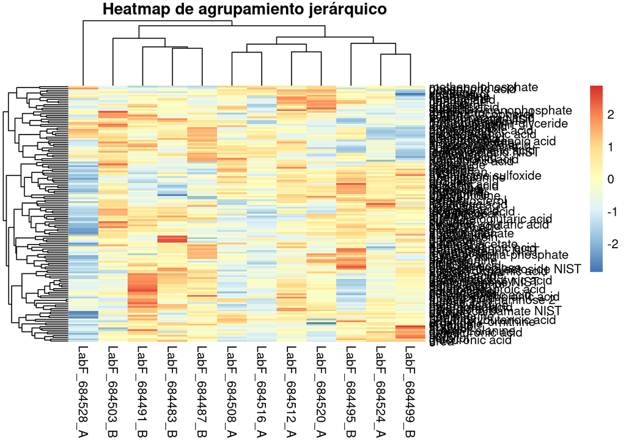

```r
library(pheatmap)
pheatmap(filtered_log_intensities, scale = "row", cluster_cols = TRUE, cluster_rows = TRUE,
         main = "Heatmap de agrupamiento jerárquico ")
```

Para el análisis de expresión diferencial y conel objetivo de identificar los metabólitos que difieren de manera significativa entre muestras provenientes de individuos transplantados y muestras de individuos que no han tenido transplante se usa el paquete limma.

```r
library(limma)
```

creamos la matriz de diseño

```r
matriz_diseño <- model.matrix(~ colData(SumExp)$Transplantation)
```

elaboración del modelo para estimar de cuan difiere la intensidad de un metabolito entre muestras de antes y muestras de después de una transplantación

```r
fit <- lmFit(filtered_log_intensities, matriz_diseño)
```

puesto que disponemos de pocas muestras, empleamos el “Empirical Bayes Smoothing” para mejorar la estimación de la varianza entre metabolitos

```r
fit <- eBayes(fit)
```

```r
metabo_signif <- topTable(fit, coef = 2, adjust = "BH", number = Inf)
```

los metabolitos que más se alteran

```r
head(metabo_signif)
```

```
##                        logFC   AveExpr         t      P.Value  adj.P.Val
## methanolphosphate  -3.845313 10.678121 -4.828971 0.0001274034 0.01809128
## levanbiose          2.913174  7.379598  4.487170 0.0002719935 0.01931154
## 2-monostearin NIST  2.191978  7.996427  4.095845 0.0006535518 0.02395569
## pyruvate            2.178515  8.176253  4.081604 0.0006748083 0.02395569
## phosphoric acid    -1.963934 14.086154 -3.892927 0.0010314969 0.02929451
## sorbitol            2.889118 10.221443  3.502860 0.0024773975 0.04817113
##                             B
## methanolphosphate   1.2542232
## levanbiose          0.5505844
## 2-monostearin NIST -0.2633774
## pyruvate           -0.2930860
## phosphoric acid    -0.6867516
## sorbitol           -1.4974664
```

Para un mejor visualización del fenómeno hacemos el Volcano plot para identificar los metabólitos más diferencialmente expresados. El volcano plot permite observar los metabolitos que al mismo tiempo que muestran alteraciones significativas, muestran alteraciones bien importantes.

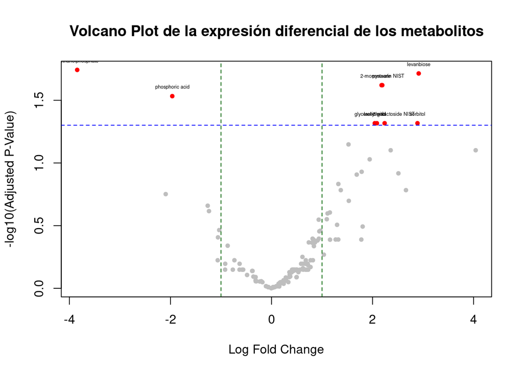

```r
plot(metabo_signif$logFC, -log10(metabo_signif$adj.P.Val),
     pch = 20, col = ifelse(metabo_signif$adj.P.Val < 0.05 & abs(metabo_signif$logFC) > 1, "red", "gray"),
     xlab = "Log Fold Change", ylab = "-log10(Adjusted P-Value)",
     main = "Volcano Plot de la expresión diferencial de los metabolitos")

abline(h = -log10(0.05), col = "blue", lty = 2)
abline(v = c(-1, 1), col = "darkgreen", lty = 2)  # definimos el threshold del LogFC
# Etiquetamos los metabolitos significativamente incrementados
significant <- which(metabo_signif$adj.P.Val < 0.05 & abs(metabo_signif$logFC) > 1)
text(metabo_signif$logFC[significant], -log10(metabo_signif$adj.P.Val[significant]),
     labels = rownames(metabo_signif)[significant], pos = 3, cex = 0.4, col = "black")
```

Se puede observar con el Volcano plot que arriba a la derecha están los metabolitos que aumentan y de manera significativa entre las dos condiciones. Arriba a la izquierda están los que disminuyen de manera significativa y abajo en el centro están aquellos que no muestran cambios significativos.

Para poder ver mejor a que metabolito corresponde cada punto en el mapa, hacemos el vulcano plot con los paquetes ggplot2 y ggrepel

```r
library(ggplot2)
```

```r
library(ggrepel)
```

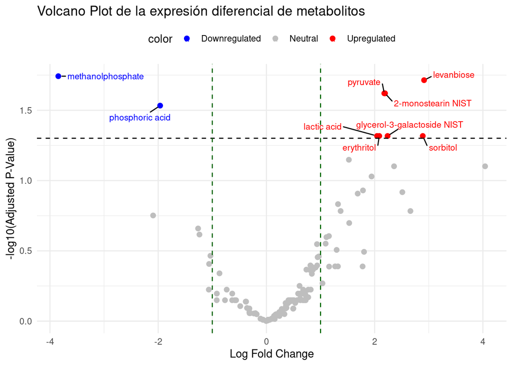

```r
# Creamos la columna color en base de la  del grado de significación y del  logFC
metabo_signif$color <- "Neutral"  # color por defecto

# Upregulated (logFC > 1 y significativo)
metabo_signif$color[metabo_signif$logFC > 1 & metabo_signif$adj.P.Val < 0.05] <- "Upregulated"

# Downregulated (logFC < -1 and significativo)
metabo_signif$color[metabo_signif$logFC < -1 & metabo_signif$adj.P.Val < 0.05] <- "Downregulated"

# crear a columna etiqueta para metabolitos significativos
metabo_signif$label <- ifelse(metabo_signif$adj.P.Val < 0.05, rownames(metabo_signif), NA)

# Dibujamo el  volcano plot
ggplot(metabo_signif, aes(x = logFC, y = -log10(adj.P.Val), color = color, label = label)) +
  geom_point(size = 2) +  # Plot points
  scale_color_manual(values = c("Neutral" = "gray", "Upregulated" = "red", "Downregulated" = "blue")) +
  geom_hline(yintercept = -log10(0.05), linetype = "dashed", color = "black") +
  geom_vline(xintercept = c(-1, 1), linetype = "dashed", color = "darkgreen") +
  geom_text_repel(aes(label = label),
                 box.padding = 0.5,
                 point.padding = 0.3,
                 min.segment.length = 0,
                 segment.color = "black",
                 size = 3,
                 max.overlaps = 15) +
  labs(title = "Volcano Plot de la expresión diferencial de metabolitos",
       x = "Log Fold Change",
       y = "-log10(Adjusted P-Value)") +
  theme_minimal() +
  theme(legend.position = "top")
```